# GSBS544 Lab 2

Author

Sahil Bains

Github Link: https://github.com/sbains2/GSBS544

## Data Set-up

```python
import pandas as pd
import numpy as np
from plotnine import *

df = pd.read_csv('avocado.csv')
df.head()
```

|  | date | average_price | total_volume | 4046 | 4225 | 4770 | total_bags | small_bags | large_bags | xlarge_bags | type | year | geography |
| --- | --- | --- | --- | --- | --- | --- | --- | --- | --- | --- | --- | --- | --- |
| 0 | 2015-01-04 | 1.22 | 40873.28 | 2819.50 | 28287.42 | 49.90 | 9716.46 | 9186.93 | 529.53 | 0.0 | conventional | 2015 | Albany |
| 1 | 2015-01-04 | 1.79 | 1373.95 | 57.42 | 153.88 | 0.00 | 1162.65 | 1162.65 | 0.00 | 0.0 | organic | 2015 | Albany |
| 2 | 2015-01-04 | 1.00 | 435021.49 | 364302.39 | 23821.16 | 82.15 | 46815.79 | 16707.15 | 30108.64 | 0.0 | conventional | 2015 | Atlanta |
| 3 | 2015-01-04 | 1.76 | 3846.69 | 1500.15 | 938.35 | 0.00 | 1408.19 | 1071.35 | 336.84 | 0.0 | organic | 2015 | Atlanta |
| 4 | 2015-01-04 | 1.08 | 788025.06 | 53987.31 | 552906.04 | 39995.03 | 141136.68 | 137146.07 | 3990.61 | 0.0 | conventional | 2015 | Baltimore/Washington |

1. This dataset contains prices and sales volumes of avocados from the years 2015-2020. The different features of the dataset include average price, total volume (sales), different PLU (price look up codes) corresponds with the specific produce characteristics associated with the avocado. PLU 4046 is classified as small/medium hass avocado (3-5 oz), 4225 are large hass avocado(8-10 oz), and 4770 are extra large hass avocados. Along with this, the are small bags, large bags, and large bags associated with each observation. Finally, there is a year associated associated with each record.
2. Cleaning the dataset

```python
df = df.dropna()
df = df.rename(columns={'4046': 'smid', '4225': 'large', '4770': 'xlarge', 'average_price': 'avg_price', 'total_volume': 'volume'})

df.info()
```

```
<class 'pandas.core.frame.DataFrame'>
RangeIndex: 33045 entries, 0 to 33044
Data columns (total 13 columns):
 #   Column       Non-Null Count  Dtype
---  ------       --------------  -----
 0   date         33045 non-null  object
 1   avg_price    33045 non-null  float64
 2   volume       33045 non-null  float64
 3   smid         33045 non-null  float64
 4   large        33045 non-null  float64
 5   xlarge       33045 non-null  float64
 6   total_bags   33045 non-null  float64
 7   small_bags   33045 non-null  float64
 8   large_bags   33045 non-null  float64
 9   xlarge_bags  33045 non-null  float64
 10  type         33045 non-null  object
 11  year         33045 non-null  int64
 12  geography    33045 non-null  object
dtypes: float64(9), int64(1), object(3)
memory usage: 3.3+ MB
```

## Exercises

3. Which major geographical region sold the most total organic, small Hass avocados in 2017?

```python
# Confirming that small hass avocados column is numeric data type
df['smid'] = pd.to_numeric(df['smid'], errors='coerce')

# Creating a mask for organic avocados in 2017 and regions
regions = ['West', 'North', 'East', 'South', 'Northwest', 'Northeast', 'Southwest', 'Southeast', 'Midsouth', 'Great Lakes', 'Plains', 'California']

mask = df[(df['type'] == 'organic') & (df['year'] == 2017) & (df['geography'].isin(regions))]

# Grouping by geography and small hass avocados, sorting the values to see highest at the top
volume_region = mask.groupby('geography')['smid'].sum().sort_values(ascending=False)

print(volume_region.sort_values(ascending=False))
```

```
geography
West           1870206.29
California     1526290.58
Northeast       925832.36
Southeast       285124.34
Great Lakes     202487.68
Midsouth        186395.50
Plains          168583.40
Name: smid, dtype: float64
```

The major geographical region that sold the most total organic, small Hass avocados in 2017 was West, with 1870206 sold.

4. Split the date variable into month, day, and year variables. In which month is the highest average volume of avocado sales?

```python
df['date'] = pd.to_datetime(df['date'])

# Splitting the variable into month, day, and year
df['month'] = df['date'].dt.month
df['day'] = df['date'].dt.day
df.head()

# Finding which month is the highest average volume of avocado sales through Groupby()
# Then finding the maximum sales volume and sorting the values based on highest volume
volume_month = df.groupby('month')['volume'].mean().sort_values(ascending=False)
print(volume_month)
```

```
month
5     1.123632e+06
2     1.095374e+06
6     1.051247e+06
4     1.016582e+06
3     9.957150e+05
1     9.853122e+05
7     9.832681e+05
8     9.499249e+05
9     9.064773e+05
10    8.446863e+05
11    8.223470e+05
12    8.076695e+05
Name: volume, dtype: float64
```

5. Which metro area geographical regions sold the most total avocados? Plot side-by-side box-plots of the total volume for only the five metro geographical regions with the highest averages for the total_volume variable.

```
geography
Los Angeles             1.567566e+06
New York                8.631458e+05
Dallas/Ft. Worth        7.127519e+05
Houston                 6.876533e+05
Phoenix/Tucson          6.250383e+05
West Tex/New Mexico     4.607743e+05
Denver                  4.541332e+05
Baltimore/Washington    4.522298e+05
San Francisco           4.480668e+05
Chicago                 4.210213e+05
Miami/Ft. Lauderdale    3.786681e+05
Portland                3.489277e+05
Boston                  3.335499e+05
Seattle                 3.307232e+05
Atlanta                 3.251538e+05
San Diego               2.839288e+05
Philadelphia            2.588769e+05
Northern New England    2.564339e+05
Sacramento              2.439074e+05
Tampa                   2.428563e+05
Detroit                 2.287954e+05
Orlando                 2.220610e+05
South Carolina          2.175841e+05
Las Vegas               1.778607e+05
Raleigh/Greensboro      1.764368e+05
Hartford/Springfield    1.709231e+05
New Orleans/Mobile      1.546839e+05
Harrisburg/Scranton     1.535562e+05
Cincinnati/Dayton       1.515242e+05
Richmond/Norfolk        1.491013e+05
Charlotte               1.328125e+05
Nashville               1.265584e+05
Indianapolis            1.085063e+05
Columbus                1.077398e+05
St. Louis               1.032092e+05
Jacksonville            1.016462e+05
Grand Rapids            9.635588e+04
Roanoke                 9.015897e+04
Buffalo/Rochester       8.366164e+04
Pittsburgh              6.714982e+04
Louisville              5.701417e+04
Albany                  5.688944e+04
Spokane                 5.029575e+04
Boise                   4.960711e+04
Syracuse                3.942599e+04
Name: volume, dtype: float64
```

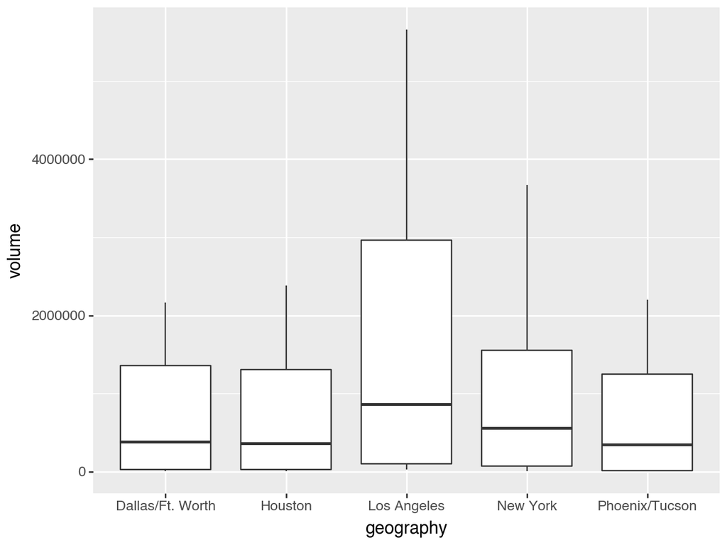

```python
# Creating a mask for organic avocados in 2017 and regions
regions = ['West', 'North', 'East', 'South', 'Northwest', 'Northeast', 'Southwest', 'Southeast', 'Midsouth', 'Great Lakes', 'Plains', 'Total U.S.', 'California', 'South Central']
metro = df[~df['geography'].isin(regions)]

# Grouping by geography and small hass avocados, sorting the values to see highest at the top
volume_region = metro.groupby('geography')['volume'].mean().sort_values(ascending=False)

print(volume_region.sort_values(ascending=False))

# Selecting top 5 geos and formatting into list
top_5 = volume_region[:5].index.tolist()

# Subsetting row level data from original mask
rows = metro[metro['geography'].isin(top_5)]


(ggplot(rows, aes(x='geography', y='volume'))
    +geom_boxplot()
)
```

## Pivot

The following four California geographical regions are in this data set: “Los Angeles”, “San Diego”, “Sacramento”, and “San Francisco”.

6. From your cleaned data set, create a data set with only these California regions and answer the following questions about these California regions only.

```python
cali = ['Los Angeles', 'San Diego', 'San Francisco', 'Sacramento']
df_cali = df[df['geography'].isin(cali)]
df_cali
```

|  | date | avg_price | volume | smid | large | xlarge | total_bags | small_bags | large_bags | xlarge_bags | type | year | geography | month | day |
| --- | --- | --- | --- | --- | --- | --- | --- | --- | --- | --- | --- | --- | --- | --- | --- |
| 44 | 2015-01-04 | 0.85 | 2682159.95 | 1837999.65 | 524430.47 | 64225.78 | 255504.05 | 215571.80 | 36981.72 | 2950.53 | conventional | 2015 | Los Angeles | 1 | 4 |
| 45 | 2015-01-04 | 1.25 | 54495.54 | 47721.51 | 1723.40 | 0.00 | 5050.63 | 5050.63 | 0.00 | 0.00 | organic | 2015 | Los Angeles | 1 | 4 |
| 80 | 2015-01-04 | 1.05 | 430138.88 | 110693.69 | 270107.61 | 9737.50 | 39600.08 | 39600.08 | 0.00 | 0.00 | conventional | 2015 | Sacramento | 1 | 4 |
| 81 | 2015-01-04 | 1.33 | 9213.49 | 3727.52 | 4327.52 | 0.00 | 1158.45 | 1158.45 | 0.00 | 0.00 | organic | 2015 | Sacramento | 1 | 4 |
| 82 | 2015-01-04 | 0.94 | 461607.33 | 244152.26 | 165299.33 | 15302.75 | 36852.99 | 30884.29 | 5595.00 | 373.70 | conventional | 2015 | San Diego | 1 | 4 |
| ... | ... | ... | ... | ... | ... | ... | ... | ... | ... | ... | ... | ... | ... | ... | ... |
| 33018 | 2020-11-29 | 1.43 | 23531.38 | 3303.69 | 2057.03 | 0.00 | 18170.66 | 18144.54 | 26.12 | 0.00 | organic | 2020 | Sacramento | 11 | 29 |
| 33019 | 2020-11-29 | 1.12 | 469356.72 | 104509.99 | 19988.45 | 7210.47 | 337647.81 | 189341.36 | 127701.64 | 20604.81 | conventional | 2020 | San Diego | 11 | 29 |
| 33020 | 2020-11-29 | 1.95 | 25799.95 | 894.63 | 838.11 | 0.00 | 24067.21 | 9691.46 | 14375.75 | 0.00 | organic | 2020 | San Diego | 11 | 29 |
| 33021 | 2020-11-29 | 1.50 | 644141.37 | 128555.43 | 136718.24 | 5597.21 | 373270.49 | 159276.65 | 207760.32 | 6233.52 | conventional | 2020 | San Francisco | 11 | 29 |
| 33022 | 2020-11-29 | 1.87 | 59527.02 | 2815.23 | 4542.30 | 0.00 | 52169.49 | 52034.33 | 135.16 | 0.00 | organic | 2020 | San Francisco | 11 | 29 |

2448 rows × 15 columns

7. In which California regions is the price of organic versus conventional avocados most different? Support your answer with a few summary statistics AND a visualization.

```
                            count      mean       std   min     25%    50%  \
geography     type
Los Angeles   conventional  306.0  1.047124  0.231167  0.53  0.8925  1.020
              organic       306.0  1.574902  0.311722  0.96  1.3425  1.585
Sacramento    conventional  306.0  1.295359  0.219177  0.86  1.1325  1.260
              organic       306.0  1.873856  0.292875  1.13  1.6700  1.840
San Diego     conventional  306.0  1.113856  0.242960  0.61  0.9425  1.090
              organic       306.0  1.798366  0.331655  1.05  1.5525  1.800
San Francisco conventional  306.0  1.400490  0.272060  0.84  1.2200  1.390
              organic       306.0  2.119444  0.395854  1.06  1.9025  2.060

                               75%   max
geography     type
Los Angeles   conventional  1.1475  1.80
              organic       1.7475  2.44
Sacramento    conventional  1.4300  1.89
              organic       2.0475  2.82
San Diego     conventional  1.2200  1.83
              organic       1.9975  2.78
San Francisco conventional  1.5675  2.20
              organic       2.3600  3.25
type           conventional   organic      diff
geography
San Francisco      1.400490  2.119444  0.718954
San Diego          1.113856  1.798366  0.684510
Sacramento         1.295359  1.873856  0.578497
Los Angeles        1.047124  1.574902  0.527778
```

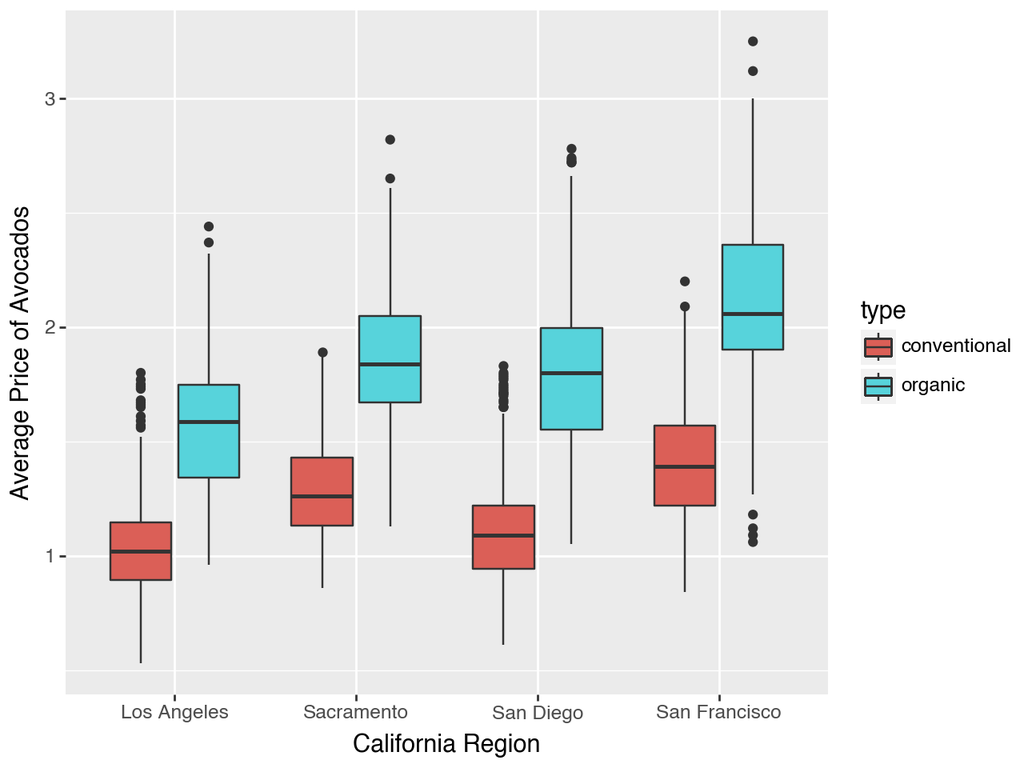

```python
# Printing summary statistics for avocados sold in California
summary = df_cali.groupby(['geography', 'type'])['avg_price'].describe()
print(summary)

# Pivoting the table to run operations on types of avocados
pivot = df_cali.pivot_table(index='geography', columns='type', values='avg_price', aggfunc='mean')

# Creating 'diff' to find absolute difference between conventional and organic
pivot['diff'] = (pivot['organic'] - pivot['conventional']).abs()
pivot = pivot.sort_values('diff', ascending=False)

print(pivot[['conventional', 'organic', 'diff']])

(
  ggplot(df_cali, aes(x='geography', y='avg_price', fill='type'))
  + geom_boxplot()
  + labs(
    x='California Region',
    y='Average Price of Avocados'
  )
)
```

In understanding some of the summary statistics of California regions and the price of organic versus conventional avocados, we see that San Francisco exhibits the highest mean sale price of organic avocados at ~$2.12. An interesting follow up is that San Francisco also has the highest deviation in the organic avocado average price at ~0.39 cents. Further more, San Francisco also has the highest difference in price of organic versus conventional avocados at ~0.72 cents. The plot confirms San Francisco as having the highest difference in average price between avocado types, and exemplifies San Diego and Los Angeles region having the most amount of outliers in the prices of conventional avocados.

8. The following plot shows, for all four California regions, the proportion of the average Hass avocado sales that are small, large, or extra large; conventional vs. organic. Recreate the plot; you do not have to replicate the exact finishing touches - e.g., color, theme - but your plot should resemble the content of this plot.

```
        geography          type    size     avg_price           sum  \
0     Los Angeles  conventional  xlarge  9.707364e+04  1.713868e+06
1     Los Angeles  conventional   large  4.438423e+05  1.713868e+06
2     Los Angeles  conventional    smid  1.172952e+06  1.713868e+06
3     Los Angeles       organic  xlarge  6.035294e+00  3.525232e+04
4     Los Angeles       organic   large  2.080422e+04  3.525232e+04
5     Los Angeles       organic    smid  1.444206e+04  3.525232e+04
6      Sacramento  conventional  xlarge  6.333280e+03  3.906215e+05
7      Sacramento  conventional   large  2.430051e+05  3.906215e+05
8      Sacramento  conventional    smid  1.412831e+05  3.906215e+05
9      Sacramento       organic  xlarge  7.726797e-01  7.092359e+03
10     Sacramento       organic   large  4.282693e+03  7.092359e+03
11     Sacramento       organic    smid  2.808893e+03  7.092359e+03
12      San Diego  conventional  xlarge  1.796354e+04  3.218624e+05
13      San Diego  conventional   large  1.401061e+05  3.218624e+05
```

[output cut: 36 more lines]

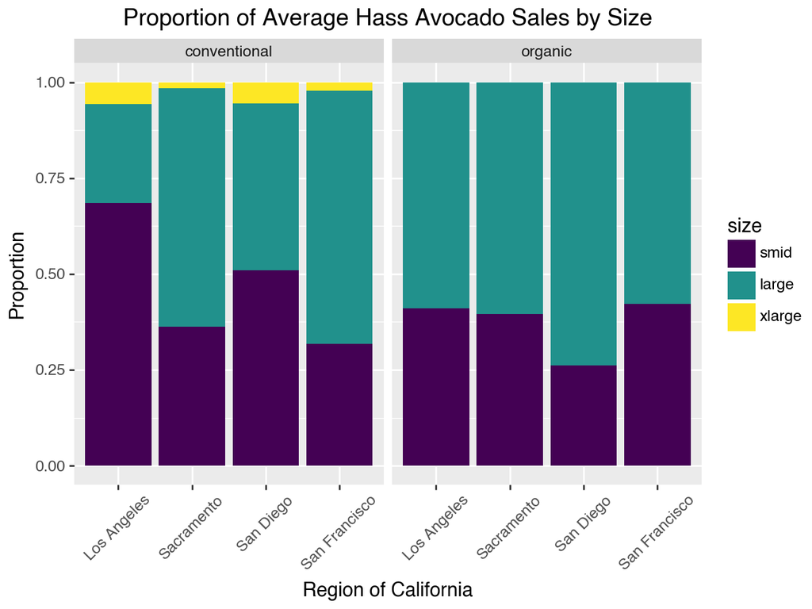

```python
# Defining sizes to pass in groupby
sizes = ['xlarge', 'large', 'smid']

# Defining prices to aggregate prices by size and type
prices = df_cali.groupby(['geography', 'type'])[sizes].mean().reset_index()

# Converting wide dataframe to long through melt()
formatted = prices.melt(id_vars=['geography', 'type'], var_name='size', value_name='avg_price')

# Calculating total by geography and type
result = formatted.groupby(['geography', 'type'])['avg_price'].sum().reset_index(name='sum')

# Merging the results back and finding the proportion based on average sales and total
formatted = formatted.merge(result, on=['geography', 'type'])
formatted['proportion'] = formatted['avg_price']/formatted['sum']
formatted['size'] = pd.Categorical(formatted['size'], categories=['smid', 'large', 'xlarge'], ordered=True)

print(formatted)

# Plotting proportion of average Hass avocado sales by size and type
(
  ggplot(formatted, aes(x='geography', y='proportion', fill='size'))
  + geom_bar(stat='identity', position=position_stack(reverse=True)) # Flipping the axes so that the xlarge size is on top
  + facet_wrap('~type') # Plotting all types
  + labs(x='Region of California', y='Proportion', title='Proportion of Average Hass Avocado Sales by Size')
  + theme(axis_text_x = element_text(angle = 45)) # Rotating x labels by 45 degrees for more room
)
```

## Using Outside Data

A joke in the media is that Millennials can’t afford houses, because they spend all their money buying avocado toast. Let’s use this data set to address that claim.

Find or assemble a data set of real data, with house prices for these four California regions. Join this data set with your California avocado data set.

Use your new joined data set to make an argument about the relationship between house prices and avocado prices/sales.

Support your argument with a plot.

```python
df_cali
```

|  | date | avg_price | volume | smid | large | xlarge | total_bags | small_bags | large_bags | xlarge_bags | type | year | geography | month | day |
| --- | --- | --- | --- | --- | --- | --- | --- | --- | --- | --- | --- | --- | --- | --- | --- |
| 44 | 2015-01-04 | 0.85 | 2682159.95 | 1837999.65 | 524430.47 | 64225.78 | 255504.05 | 215571.80 | 36981.72 | 2950.53 | conventional | 2015 | Los Angeles | 1 | 4 |
| 45 | 2015-01-04 | 1.25 | 54495.54 | 47721.51 | 1723.40 | 0.00 | 5050.63 | 5050.63 | 0.00 | 0.00 | organic | 2015 | Los Angeles | 1 | 4 |
| 80 | 2015-01-04 | 1.05 | 430138.88 | 110693.69 | 270107.61 | 9737.50 | 39600.08 | 39600.08 | 0.00 | 0.00 | conventional | 2015 | Sacramento | 1 | 4 |
| 81 | 2015-01-04 | 1.33 | 9213.49 | 3727.52 | 4327.52 | 0.00 | 1158.45 | 1158.45 | 0.00 | 0.00 | organic | 2015 | Sacramento | 1 | 4 |
| 82 | 2015-01-04 | 0.94 | 461607.33 | 244152.26 | 165299.33 | 15302.75 | 36852.99 | 30884.29 | 5595.00 | 373.70 | conventional | 2015 | San Diego | 1 | 4 |
| ... | ... | ... | ... | ... | ... | ... | ... | ... | ... | ... | ... | ... | ... | ... | ... |
| 33018 | 2020-11-29 | 1.43 | 23531.38 | 3303.69 | 2057.03 | 0.00 | 18170.66 | 18144.54 | 26.12 | 0.00 | organic | 2020 | Sacramento | 11 | 29 |
| 33019 | 2020-11-29 | 1.12 | 469356.72 | 104509.99 | 19988.45 | 7210.47 | 337647.81 | 189341.36 | 127701.64 | 20604.81 | conventional | 2020 | San Diego | 11 | 29 |
| 33020 | 2020-11-29 | 1.95 | 25799.95 | 894.63 | 838.11 | 0.00 | 24067.21 | 9691.46 | 14375.75 | 0.00 | organic | 2020 | San Diego | 11 | 29 |
| 33021 | 2020-11-29 | 1.50 | 644141.37 | 128555.43 | 136718.24 | 5597.21 | 373270.49 | 159276.65 | 207760.32 | 6233.52 | conventional | 2020 | San Francisco | 11 | 29 |
| 33022 | 2020-11-29 | 1.87 | 59527.02 | 2815.23 | 4542.30 | 0.00 | 52169.49 | 52034.33 | 135.16 | 0.00 | organic | 2020 | San Francisco | 11 | 29 |

2448 rows × 15 columns

Importing

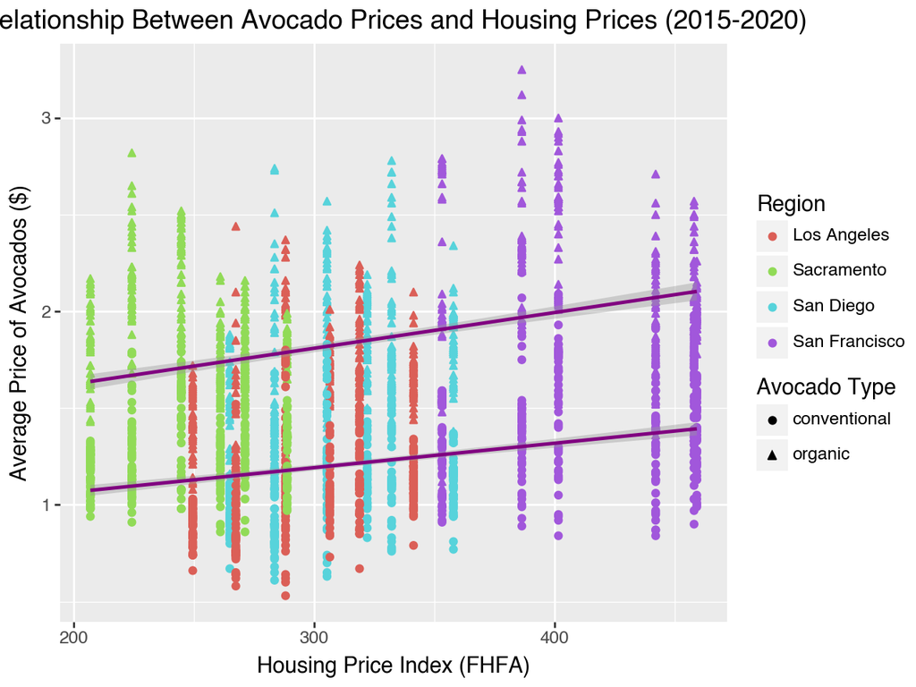

```python
# Reading in new dataset
housing = pd.read_csv('HousingPriceIndex.csv')

# Filtering the years to 2015-2020 and associated regions to match california regions
regions = ['San Francisco-San Mateo-Redwood City, CA (MSAD)', 'San Diego-Chula Vista-Carlsbad, CA', 'Sacramento-Roseville-Folsom, CA', 'Los Angeles-Long Beach-Glendale, CA (MSAD)']

housing = housing[(housing['yr'] >= 2015) & (housing['yr'] <= 2020) & housing['place_name'].isin(regions)]

# Renaming columns and row values to join on avocado dataset
housing = housing.rename(columns={'place_name': 'geography', 'yr': 'year', 'index_nsa': 'hpi'})
housing['geography'] = housing['geography'].replace({
    'San Francisco-San Mateo-Redwood City, CA (MSAD)': 'San Francisco',
    'San Diego-Chula Vista-Carlsbad, CA': 'San Diego',
    'Sacramento-Roseville-Folsom, CA': 'Sacramento',
    'Los Angeles-Long Beach-Glendale, CA (MSAD)': 'Los Angeles'
})

# Dropping irrelevant columns
housing = housing.drop(columns={'hpi_type', 'hpi_flavor', 'level', 'index_sa'})

# Collapse housing to annual level
housing_formatted = (housing.groupby(['geography', 'year'])['hpi'].mean().reset_index())

# Merging with avocado california dataframe
avo_house = df_cali.merge(housing_formatted, left_on=['geography', 'year'], right_on=['geography', 'year'])

# Plotting avocado sales with housing price index
(
  ggplot(avo_house, aes(x='hpi', y='avg_price', color='geography', shape='type'))
  + geom_point()
  + geom_smooth(color='purple')
  + labs(
    title='Relationship Between Avocado Prices and Housing Prices (2015-2020)',
    y='Average Price of Avocados ($)',
    x='Housing Price Index (FHFA)',
    color='Region',
    shape='Avocado Type'
  )
)
```

After joining the FHFA housing price index for California regions and joining it to the Avocado sales dataset, we’re able to interpret that higher changes in the housing market do not exhibit a strong or consistent relationship with average avocado prices.

For example, in Sacramento, as the housing price index increased, avocado prices decreased, which signal that housing market shifts do not directly influence consumer pricing on produce products. Conversely, with greater changes in the San Francisco housing market, there seemed to be a gental increase in avocado prices until the Housing Price Index reached ~470.

Overall, while housing prices and the average price of avocados generally increased over the years, local demographic and other economic drivers most likely influenced the changes on each market independently.